# Data cleaning for the Price prediction of apartments in Barcelona

Viktória Kónya

10 February, 2022

What the code does:

- Imports Barcelona Airbnb data from GitHub repo
- Sample selection
- Data cleaning and feature engineering
- Saves the workfile

# Data import

```r
# Import data - 15.707 obs, 74 vars
# listings <- read_csv("https://raw.githubusercontent.com/viktoriakonya/CEU-DA3/main/A2/data/raw/listings_20211207.csv")
listings <- read_csv(paste0(data_raw,"/listings_20211207.csv"))

# Convert to data table
df <- data.table(listings)

# Look at the dataset - 74 vars; 15.707 obs.
skim(listings)
```

Data summary

| Name | listings |
| --- | --- |
| Number of rows | 15707 |
| Number of columns | 74 |
| _______________________ |  |
| Column type frequency: |  |
| character | 25 |
| Date | 5 |
| logical | 7 |
| numeric | 37 |
| ________________________ |  |
| Group variables | None |

**Variable type: character**

| skim_variable | n_missing | complete_rate | min | max | empty | n_unique | whitespace |
| --- | --- | --- | --- | --- | --- | --- | --- |
| listing_url | 0 | 1.00 | 34 | 37 | 0 | 15707 | 0 |
| name | 10 | 1.00 | 1 | 255 | 0 | 15289 | 0 |
| description | 92 | 0.99 | 1 | 1000 | 0 | 14262 | 0 |
| neighborhood_overview | 6519 | 0.58 | 1 | 1000 | 0 | 6812 | 0 |
| picture_url | 0 | 1.00 | 61 | 126 | 0 | 15481 | 0 |
| host_url | 0 | 1.00 | 38 | 43 | 0 | 7126 | 0 |
| host_name | 36 | 1.00 | 1 | 35 | 0 | 3318 | 0 |
| host_location | 49 | 1.00 | 2 | 166 | 0 | 617 | 0 |
| host_about | 5736 | 0.63 | 1 | 5729 | 0 | 3796 | 6 |
| host_response_time | 36 | 1.00 | 3 | 18 | 0 | 5 | 0 |
| host_response_rate | 36 | 1.00 | 2 | 4 | 0 | 62 | 0 |
| host_acceptance_rate | 36 | 1.00 | 2 | 4 | 0 | 96 | 0 |
| host_thumbnail_url | 36 | 1.00 | 55 | 106 | 0 | 7081 | 0 |
| host_picture_url | 36 | 1.00 | 57 | 109 | 0 | 7081 | 0 |
| host_neighbourhood | 4883 | 0.69 | 3 | 33 | 0 | 132 | 0 |
| host_verifications | 0 | 1.00 | 2 | 156 | 0 | 271 | 0 |
| neighbourhood | 6519 | 0.58 | 5 | 55 | 0 | 67 | 0 |
| neighbourhood_cleansed | 0 | 1.00 | 5 | 44 | 0 | 71 | 0 |
| neighbourhood_group_cleansed | 0 | 1.00 | 6 | 19 | 0 | 10 | 0 |
| property_type | 0 | 1.00 | 4 | 35 | 0 | 56 | 0 |
| room_type | 0 | 1.00 | 10 | 15 | 0 | 4 | 0 |
| bathrooms_text | 17 | 1.00 | 6 | 17 | 0 | 37 | 0 |
| amenities | 0 | 1.00 | 2 | 2101 | 0 | 13186 | 0 |
| price | 0 | 1.00 | 5 | 9 | 0 | 473 | 0 |
| license | 5621 | 0.64 | 1 | 243 | 0 | 4889 | 0 |

**Variable type: Date**

| skim_variable | n_missing | complete_rate | min | max | median | n_unique |
| --- | --- | --- | --- | --- | --- | --- |
| last_scraped | 0 | 1.00 | 2021-12-07 | 2021-12-08 | 2021-12-08 | 2 |
| host_since | 36 | 1.00 | 2008-09-19 | 2021-12-02 | 2016-03-04 | 2985 |
| calendar_last_scraped | 0 | 1.00 | 2021-12-07 | 2021-12-08 | 2021-12-08 | 2 |
| first_review | 4084 | 0.74 | 2010-10-03 | 2021-12-06 | 2018-08-19 | 2933 |
| last_review | 4084 | 0.74 | 2011-06-23 | 2021-12-07 | 2021-09-12 | 1597 |

**Variable type: logical**

| skim_variable | n_missing | complete_rate | mean | count |
| --- | --- | --- | --- | --- |
| host_is_superhost | 36 | 1 | 0.17 | FAL: 13078, TRU: 2593 |
| host_has_profile_pic | 36 | 1 | 1.00 | TRU: 15605, FAL: 66 |
| host_identity_verified | 36 | 1 | 0.79 | TRU: 12325, FAL: 3346 |
| bathrooms | 15707 | 0 | NaN | : |
| calendar_updated | 15707 | 0 | NaN | : |
| has_availability | 0 | 1 | 0.99 | TRU: 15494, FAL: 213 |
| instant_bookable | 0 | 1 | 0.45 | FAL: 8643, TRU: 7064 |

**Variable type: numeric**

| skim_variable | n_missing | complete_rate | mean | sd | p0 | p25 | p50 | p75 | p100 | hist |
| --- | --- | --- | --- | --- | --- | --- | --- | --- | --- | --- |
| id | 0 | 1.00 | 2.868094e+07 | 16351001.91 | 1.867400e+04 | 1.520037e+07 | 3.000325e+07 | 4.285531e+07 | 5.371388e+07 | ▆▆▆▇▇ |
| scrape_id | 0 | 1.00 | 2.021121e+13 | 0.00 | 2.021121e+13 | 2.021121e+13 | 2.021121e+13 | 2.021121e+13 | 2.021121e+13 | ▁▁▇▁▁ |
| host_id | 0 | 1.00 | 1.200667e+08 | 125657447.39 | 3.073000e+03 | 8.867952e+06 | 6.167434e+07 | 2.207932e+08 | 4.343499e+08 | ▇▂▂▂▁ |
| host_listings_count | 36 | 1.00 | 6.493000e+01 | 382.71 | 0.000000e+00 | 1.000000e+00 | 3.000000e+00 | 1.600000e+01 | 3.750000e+03 | ▇▁▁▁▁ |
| host_total_listings_count | 36 | 1.00 | 6.493000e+01 | 382.71 | 0.000000e+00 | 1.000000e+00 | 3.000000e+00 | 1.600000e+01 | 3.750000e+03 | ▇▁▁▁▁ |
| latitude | 0 | 1.00 | 4.139000e+01 | 0.01 | 4.135000e+01 | 4.138000e+01 | 4.139000e+01 | 4.140000e+01 | 4.146000e+01 | ▁▇▅▁▁ |
| longitude | 0 | 1.00 | 2.170000e+00 | 0.02 | 2.090000e+00 | 2.160000e+00 | 2.170000e+00 | 2.180000e+00 | 2.230000e+00 | ▁▂▇▆▁ |
| accommodates | 0 | 1.00 | 3.370000e+00 | 2.23 | 0.000000e+00 | 2.000000e+00 | 2.000000e+00 | 4.000000e+00 | 1.600000e+01 | ▇▅▁▁▁ |
| bedrooms | 593 | 0.96 | 1.680000e+00 | 1.02 | 1.000000e+00 | 1.000000e+00 | 1.000000e+00 | 2.000000e+00 | 1.600000e+01 | ▇▁▁▁▁ |
| beds | 697 | 0.96 | 2.400000e+00 | 1.92 | 1.000000e+00 | 1.000000e+00 | 2.000000e+00 | 3.000000e+00 | 4.000000e+01 | ▇▁▁▁▁ |
| minimum_nights | 0 | 1.00 | 1.444000e+01 | 36.06 | 1.000000e+00 | 1.000000e+00 | 3.000000e+00 | 3.000000e+01 | 1.124000e+03 | ▇▁▁▁▁ |
| maximum_nights | 0 | 1.00 | 6.997500e+02 | 491.15 | 1.000000e+00 | 1.200000e+02 | 1.125000e+03 | 1.125000e+03 | 3.000000e+03 | ▆▇▁▁▁ |
| minimum_minimum_nights | 1 | 1.00 | 1.474000e+01 | 36.36 | 1.000000e+00 | 1.000000e+00 | 2.000000e+00 | 3.000000e+01 | 1.124000e+03 | ▇▁▁▁▁ |
| maximum_minimum_nights | 1 | 1.00 | 1.688000e+01 | 38.00 | 1.000000e+00 | 2.000000e+00 | 4.000000e+00 | 3.000000e+01 | 1.124000e+03 | ▇▁▁▁▁ |
| minimum_maximum_nights | 1 | 1.00 | 7.820700e+02 | 545.09 | 1.000000e+00 | 3.000000e+02 | 1.125000e+03 | 1.125000e+03 | 9.999000e+03 | ▇▁▁▁▁ |
| maximum_maximum_nights | 1 | 1.00 | 2.742628e+05 | 24232491.96 | 1.000000e+00 | 3.340000e+02 | 1.125000e+03 | 1.125000e+03 | 2.147484e+09 | ▇▁▁▁▁ |
| minimum_nights_avg_ntm | 1 | 1.00 | 1.572000e+01 | 37.05 | 1.000000e+00 | 2.000000e+00 | 3.000000e+00 | 3.000000e+01 | 1.124000e+03 | ▇▁▁▁▁ |
| maximum_nights_avg_ntm | 1 | 1.00 | 2.736352e+05 | 24177667.43 | 1.000000e+00 | 3.300000e+02 | 1.125000e+03 | 1.125000e+03 | 2.142625e+09 | ▇▁▁▁▁ |
| availability_30 | 0 | 1.00 | 9.600000e+00 | 10.82 | 0.000000e+00 | 0.000000e+00 | 5.000000e+00 | 1.900000e+01 | 3.000000e+01 | ▇▂▂▂▂ |
| availability_60 | 0 | 1.00 | 2.364000e+01 | 22.83 | 0.000000e+00 | 0.000000e+00 | 2.000000e+01 | 4.600000e+01 | 6.000000e+01 | ▇▂▂▂▃ |
| availability_90 | 0 | 1.00 | 3.889000e+01 | 34.80 | 0.000000e+00 | 0.000000e+00 | 3.600000e+01 | 7.300000e+01 | 9.000000e+01 | ▇▂▂▃▅ |
| availability_365 | 0 | 1.00 | 1.747100e+02 | 138.38 | 0.000000e+00 | 1.300000e+01 | 1.790000e+02 | 3.160000e+02 | 3.650000e+02 | ▇▂▂▃▇ |
| number_of_reviews | 0 | 1.00 | 3.582000e+01 | 69.29 | 0.000000e+00 | 0.000000e+00 | 5.000000e+00 | 3.800000e+01 | 8.830000e+02 | ▇▁▁▁▁ |
| number_of_reviews_ltm | 0 | 1.00 | 5.130000e+00 | 11.55 | 0.000000e+00 | 0.000000e+00 | 0.000000e+00 | 5.000000e+00 | 4.600000e+02 | ▇▁▁▁▁ |
| number_of_reviews_l30d | 0 | 1.00 | 6.000000e-01 | 1.69 | 0.000000e+00 | 0.000000e+00 | 0.000000e+00 | 0.000000e+00 | 7.200000e+01 | ▇▁▁▁▁ |
| review_scores_rating | 4084 | 0.74 | 4.500000e+00 | 0.72 | 0.000000e+00 | 4.400000e+00 | 4.670000e+00 | 4.890000e+00 | 5.000000e+00 | ▁▁▁▁▇ |
| review_scores_accuracy | 4232 | 0.73 | 4.640000e+00 | 0.52 | 0.000000e+00 | 4.540000e+00 | 4.790000e+00 | 4.950000e+00 | 5.000000e+00 | ▁▁▁▁▇ |
| review_scores_cleanliness | 4230 | 0.73 | 4.580000e+00 | 0.55 | 0.000000e+00 | 4.450000e+00 | 4.730000e+00 | 4.930000e+00 | 5.000000e+00 | ▁▁▁▁▇ |
| review_scores_checkin | 4236 | 0.73 | 4.730000e+00 | 0.47 | 0.000000e+00 | 4.680000e+00 | 4.880000e+00 | 5.000000e+00 | 5.000000e+00 | ▁▁▁▁▇ |
| review_scores_communication | 4231 | 0.73 | 4.730000e+00 | 0.48 | 0.000000e+00 | 4.670000e+00 | 4.880000e+00 | 5.000000e+00 | 5.000000e+00 | ▁▁▁▁▇ |
| review_scores_location | 4237 | 0.73 | 4.750000e+00 | 0.39 | 0.000000e+00 | 4.680000e+00 | 4.860000e+00 | 5.000000e+00 | 5.000000e+00 | ▁▁▁▁▇ |
| review_scores_value | 4238 | 0.73 | 4.500000e+00 | 0.53 | 0.000000e+00 | 4.350000e+00 | 4.620000e+00 | 4.800000e+00 | 5.000000e+00 | ▁▁▁▁▇ |
| calculated_host_listings_count | 0 | 1.00 | 1.843000e+01 | 35.37 | 1.000000e+00 | 1.000000e+00 | 3.000000e+00 | 1.600000e+01 | 1.780000e+02 | ▇▁▁▁▁ |
| calculated_host_listings_count_entire_homes | 0 | 1.00 | 1.457000e+01 | 32.40 | 0.000000e+00 | 0.000000e+00 | 1.000000e+00 | 1.200000e+01 | 1.780000e+02 | ▇▁▁▁▁ |
| calculated_host_listings_count_private_rooms | 0 | 1.00 | 3.220000e+00 | 13.20 | 0.000000e+00 | 0.000000e+00 | 0.000000e+00 | 1.000000e+00 | 1.010000e+02 | ▇▁▁▁▁ |
| calculated_host_listings_count_shared_rooms | 0 | 1.00 | 5.200000e-01 | 4.46 | 0.000000e+00 | 0.000000e+00 | 0.000000e+00 | 0.000000e+00 | 4.500000e+01 | ▇▁▁▁▁ |
| reviews_per_month | 4084 | 0.74 | 1.070000e+00 | 1.28 | 1.000000e-02 | 1.700000e-01 | 6.300000e-01 | 1.570000e+00 | 2.549000e+01 | ▇▁▁▁▁ |

# Sample selection

### 1. step: Filter for Entire home / Apartments only

```r
df[, .(count = .N), by = .(room_type)]
```

```
##          room_type count
## 1: Entire home/apt  8407
## 2:    Private room  6858
## 3:      Hotel room   220
## 4:     Shared room   222
```

```r
# Entire home / Apartments only - 8.407 obs.
df <- df[room_type %in% c("Entire home/apt")]
```

### 2. step: Filter out irrelevant property types

```r
df[, .(count = .N), by = .(property_type)]
```

```
##                  property_type count
##  1:         Entire rental unit  7246
##  2:                Entire loft   271
##  3:  Entire serviced apartment   399
##  4: Entire condominium (condo)   258
##  5:    Entire residential home    70
##  6:                       Boat    31
##  7:         Entire guest suite    43
##  8:           Entire townhouse    18
##  9:               Entire villa    15
## 10:                 Tiny house     4
## 11:          Entire guesthouse    23
## 12:                       Barn     1
## 13:                      Floor     1
## 14:               Entire place     4
## 15:            Entire home/apt     1
## 16:              Entire chalet     2
## 17:                  Camper/RV     7
## 18:         Room in aparthotel     4
## 19:            Casa particular     2
## 20:       Entire vacation home     7
```

```r
# Relevant property types only  - 8.341 obs.
df <- df[!(property_type %in% c("Boat", "Barn", "Floor", "Camper/RV", "", "Room in aparthotel", "Entire vacation home", "Entire villa"))]
```

**Note**: Later categories with few listings chould be grouped.

### 3. step: Filter for apartments with 2-6 accommodates

```r
df[, .(count = .N), by = .(accommodates)][order(accommodates)]
```

```
##     accommodates count
##  1:            1    37
##  2:            2  1409
##  3:            3   716
##  4:            4  2658
##  5:            5   997
##  6:            6  1480
##  7:            7   269
##  8:            8   420
##  9:            9    85
## 10:           10   139
## 11:           11     9
## 12:           12    40
## 13:           13    10
## 14:           14    23
## 15:           15     9
## 16:           16    40
```

```r
# Apartments with 2-6 accommodates - 7260 obs.
df <- df[accommodates >= 2 & accommodates <= 6]
```

### 4. step: Filter for apartments where the number of beds <= 6 or NA

```r
df[, .(count = .N), by = .(beds)][order(beds)]
```

```
##     beds count
##  1:    1  1369
##  2:    2  1983
##  3:    3  1850
##  4:    4  1188
##  5:    5   505
##  6:    6   212
##  7:    7    11
##  8:    8     4
##  9:   10     3
## 10:   15     1
## 11:   NA   134
```

```r
# Apartments with beds <= 6 - 7241 obs.
df <- df[beds <= 6 | is.na(beds)]
```

**Note**: NAs should be imputed later.

### 5. step: Filter out apartments with 0 bathrooms

```r
df[,.(count = .N), by =.(bathrooms_text)] # 1 obs.
```

```
##     bathrooms_text count
##  1:        2 baths  1643
##  2:      1.5 baths   406
##  3:         1 bath  5071
##  4:           <NA>     1
##  5:        3 baths    63
##  6:      2.5 baths    41
##  7:        4 baths     5
##  8:      Half-bath     3
##  9:      3.5 baths     7
## 10:        0 baths     1
```

```r
# Apartments with bathrooms > 0 - 7240 obs.
df <- df[bathrooms_text != "0 baths" | is.na(bathrooms_text)]
```

**Note**: NA should be imputed later.

### 6. step: Filter out apartments with minimum nights > 90 days

```r
df[minimum_nights > 90,.(count = .N)] # 61 obs.
```

```
##    count
## 1:    61
```

```r
# Apartments with bathrooms > 0 - 7179 obs.
df <- df[minimum_nights <= 90]
```

# Drop useless fields and with high missing rate

```r
# Check variables with only missing values
missings <- sapply(df, function(x) sum(is.na(x)))
missings[missings > 0]
```

```
##                 description       neighborhood_overview
##                          26                        2776
##                   host_name                  host_since
##                          24                          24
##               host_location                  host_about
##                          29                        1884
##          host_response_time          host_response_rate
##                          24                          24
##        host_acceptance_rate           host_is_superhost
##                          24                          24
##          host_thumbnail_url            host_picture_url
##                          24                          24
##          host_neighbourhood         host_listings_count
##                        1686                          24
##   host_total_listings_count        host_has_profile_pic
##                          24                          24
##      host_identity_verified               neighbourhood
##                          24                        2776
##                   bathrooms              bathrooms_text
##                        7179                           1
##                    bedrooms                        beds
##                         338                         133
##            calendar_updated                first_review
##                        7179                        1585
##                 last_review        review_scores_rating
##                        1585                        1585
##      review_scores_accuracy   review_scores_cleanliness
##                        1612                        1612
##       review_scores_checkin review_scores_communication
##                        1613                        1611
##      review_scores_location         review_scores_value
##                        1612                        1612
##                     license           reviews_per_month
##                        2203                        1585
```

```r
# calendar_updated, bathrooms have only missings

# Drop variables with only NA, host-related information and useless fields
drops <- c("listing_url", "scrape_id", "last_scraped", "name", "description", "neighborhood_overview",
           "picture_url", "host_id", "host_url", "host_name", "host_since", "host_location", "host_about", "host_response_time",
           "host_response_rate", "host_acceptance_rate", "host_is_superhost",
           "host_thumbnail_url","host_picture_url","host_neighbourhood", "host_listings_count",
           "host_total_listings_count", "host_verifications", "host_has_profile_pic", "host_identity_verified",
           "minimum_minimum_nights", "maximum_minimum_nights", "minimum_maximum_nights", "maximum_maximum_nights",
           "minimum_nights_avg_ntm", "maximum_nights_avg_ntm","availability_60", "availability_90", "availability_365",
           "number_of_reviews_ltm", "number_of_reviews_l30d", "first_review", "last_review",
           "review_scores_accuracy", "review_scores_cleanliness", "review_scores_checkin", "review_scores_communication",
           "review_scores_location", "review_scores_value", "license", "calculated_host_listings_count",
           "calculated_host_listings_count_private_rooms", "reviews_per_month",
           "bathrooms", "calendar_updated"
           )

# 24 vars, 7.240 obs
df <- df[, (drops) := NULL]
```

# Data cleaning

### 1. step: Price per night

```r
# Clean outcome var and rename
df$price <- gsub("\\,","",df$price) # delete commas
df$n_price <- as.numeric(gsub("\\$","",df$price)) # delete $ from the end

# Missings
datasummary_skim(df$n_price) # 0 missing
```

|  | Unique (#) | Missing (%) | Mean | SD | Min | Median | Max |  |
| --- | --- | --- | --- | --- | --- | --- | --- | --- |
| data | 340 | 0 | 113.1 | 206.9 | 8.0 | 91.0 | 9999.0 |  |

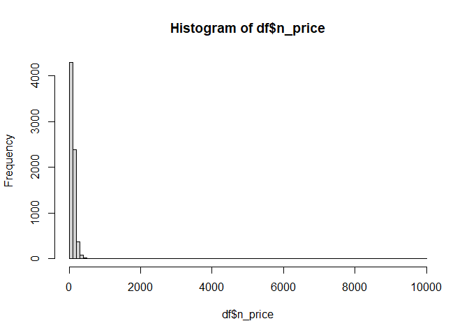

```r
# Distribution
hist(df$n_price, breaks = 100) # Highly right-skewed, 16 extrem above 1000 USD
```

```r
# Price distr. by property type
df[, .(count = .N, min_price = min(n_price), max_price = max(n_price)), by = .(property_type)]
```

```
##                  property_type count min_price max_price
##  1:         Entire rental unit  6211         8      9999
##  2:                Entire loft   258        12       999
##  3:  Entire serviced apartment   355        36      1027
##  4: Entire condominium (condo)   230        22       329
##  5:         Entire guest suite    42        28       190
##  6:           Entire townhouse    10        40       298
##  7:    Entire residential home    41         9      2000
##  8:                 Tiny house     3        30       123
##  9:          Entire guesthouse    21        28       150
## 10:               Entire place     4        53       150
## 11:            Entire home/apt     1       102       102
## 12:            Casa particular     2        84       106
## 13:              Entire chalet     1        46        46
```

```r
# Distribution is highly skewed -> Take log of prices (no 0 values)
# df$n_ln_price <- log(df$n_price)
```

**Note**: Price per night is highly right-skewed with 40 listings above 600 USD and 16 extreme listings above 1000 USD. As these listings are irrelevalant for our analysis hence they were excluded them later from the analysis.

### 2. step: Bathrooms

```r
# Summary
df[, .(count = .N), by = .(bathrooms_text)][order(bathrooms_text)] # 3 not numeric, 1 NA
```

```
##    bathrooms_text count
## 1:         1 bath  5035
## 2:      1.5 baths   404
## 3:        2 baths  1620
## 4:      2.5 baths    41
## 5:        3 baths    63
## 6:      3.5 baths     7
## 7:        4 baths     5
## 8:      Half-bath     3
## 9:           <NA>     1
```

```r
# Add number to the beginning
df$bathrooms_text_mod <- ifelse(df$bathrooms_text == "Shared half-bath", "0.5 shared half-bath", df$bathrooms_text)
df$bathrooms_text_mod <- ifelse(df$bathrooms_text == "Half-bath", "0.5 half-bath", df$bathrooms_text_mod)
df$bathrooms_text_mod <- ifelse(df$bathrooms_text == "Private half-bath", "0.5 private half-bath", df$bathrooms_text_mod)

# Create variable for number of bathroom
df$n_bathrooms <- as.numeric(sub( " .*$", "", df$bathrooms_text_mod ))

# Check
df[, .(count = .N), by = .(bathrooms_text, bathrooms_text_mod, n_bathrooms)][order(bathrooms_text)]
```

```
##    bathrooms_text bathrooms_text_mod n_bathrooms count
## 1:         1 bath             1 bath         1.0  5035
## 2:      1.5 baths          1.5 baths         1.5   404
## 3:        2 baths            2 baths         2.0  1620
## 4:      2.5 baths          2.5 baths         2.5    41
## 5:        3 baths            3 baths         3.0    63
## 6:      3.5 baths          3.5 baths         3.5     7
## 7:        4 baths            4 baths         4.0     5
## 8:      Half-bath      0.5 half-bath         0.5     3
## 9:           <NA>               <NA>          NA     1
```

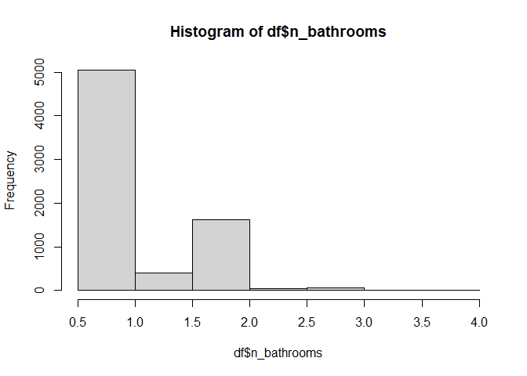

```r
# 1 NA and 1 with 0
hist(df$n_bathrooms, breaks = 10)
```

```r
# Create factor for bathroom with 3 levels: [0-0.5], [1-1.5], [2+]
df[, f_bathrooms:= cut(n_bathrooms, c(1,2,3,10), labels=c(1,2,3), right = F)  ]
df[, .(count = .N, min = min(n_bathrooms), max = max(n_bathrooms)), by = .(f_bathrooms)]
```

```
##    f_bathrooms count min max
## 1:           2  1661   2 2.5
## 2:           1  5439   1 1.5
## 3:        <NA>     4  NA  NA
## 4:           3    75   3 4.0
```

**Note**: The bathroom field of the dataset was not reliable, hence I used the text field to create this variable. A there are very few observations above 3 bathrooms we can create categories of the bathroom number later.

### 3. step: Amenities

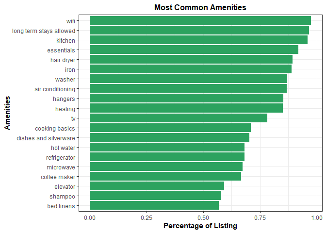

```r
# Clean list
df$amenities <- gsub("\\{","",df$amenities)
df$amenities <- gsub("\\}","",df$amenities)
df$amenities <- gsub('\\"',"",df$amenities)
df$amenities <- gsub('\\[',"",df$amenities)
df$amenities <- gsub('\\]',"",df$amenities)
df$amenities <- tolower(df$amenities)

# Check most frequent items
out_db <- df %>%
  mutate(amenities = tolower(amenities))

list_amenities <- map(out_db$amenities, function(x) x %>% strsplit(", ") %>% unlist() ) %>%
  unlist()

df_amenities <- data.frame(amenities = list_amenities)

df_viz <- df_amenities %>%
  count(amenities, name = "frequency") %>%
  mutate(n_data = nrow(out_db),
         ratio = frequency/nrow(out_db)) %>%
  arrange(desc(ratio)) %>%
  head(20)

p <- df_viz %>%
  ggplot(aes(x = ratio,
             y = amenities %>% reorder(ratio))) +
  geom_col(fill = "#2ca25f") +
  labs(x = "Percentage of Listing",
       y = "Amenities",
       title = "Most Common Amenities") +
  theme_bw() +
  theme(
    plot.title = element_text(size = 12L,
                              face = "bold", hjust = 0.5),
    axis.title.y = element_text(face = "bold"),
    axis.title.x = element_text(face = "bold"),
    legend.position = "none"
  )

p
```

```r
# Save plot
ggsave(paste0(output, "/top_20_amenities.jpg"), p, width = 6, height = 6)


# Add dummies for the most frequent and sensible amenities
df[, d_wifi := ifelse(df$amenities %like% "wifi" == T, 1, 0)]
df[, d_long_term_stays_allowed := ifelse(df$amenities %like% "long term stays" == T, 1, 0)]
# df[, d_essentials := ifelse(df$amenities %like% "essentials" == T, 1, 0)]
df[, d_kitchen := ifelse(df$amenities %like% "kitchen" == T, 1, 0)]
# df[, d_hangers := ifelse(df$amenities %like% "hangers" == T, 1, 0)]
# df[, d_hair_dryer := ifelse(df$amenities %like% "hair dryer" == T, 1, 0)]
# df[, d_heating := ifelse(df$amenities %like% "heating" == T, 1, 0)]
df[, d_washer := ifelse(df$amenities %like% "washer" == T, 1, 0)]
# df[, d_iron := ifelse(df$amenities %like% "iron" == T, 1, 0)]
# df[, d_hot_water := ifelse(df$amenities %like% "hot water" == T, 1, 0)]
df[, d_air_conditioning := ifelse(df$amenities %like% "air conditioning" == T, 1, 0)]
df[, d_tv := ifelse(df$amenities %like% "tv" == T, 1, 0)]
# df[, d_shampoo := ifelse(df$amenities %like% "shampoo" == T, 1, 0)]
df[, d_elevator := ifelse(df$amenities %like% "elevator" == T, 1, 0)]
# df[, d_dishes_and_silverware := ifelse(df$amenities %like% "dishes and silverware" == T, 1, 0)]
df[, d_cooking_basics := ifelse(df$amenities %like% "cooking basics" == T, 1, 0)]
# df[, d_refrigerator := ifelse(df$amenities %like% "refrigerator" == T | df$amenities %like% "fridge" == T, 1, 0)]
df[, d_dedicated_workspace := ifelse(df$amenities %like% "dedicated workspace" == T, 1, 0)]
# df[, d_microwave := ifelse(df$amenities %like% "microwave" == T, 1, 0)]
# df[, d_coffee_maker:= ifelse(df$amenities %like% "coffee maker" == T, 1, 0)]

df[, d_breakfast := ifelse(df$amenities %like% "breakfast" == T, 1, 0)]
df[, d_children_friendly := ifelse(df$amenities %like% "children" == T | df$amenities %like% "baby" == T, 1, 0)]
# df[, d_closet := ifelse(df$amenities %like% "closet" == T, 1, 0)]
df[, d_garden := ifelse(df$amenities %like% "garden" == T | df$amenities %like%  "backyard" == T, 1, 0)]
# df[, d_first_aid_kit := ifelse(df$amenities %like% "first aid kit" == T, 1, 0)]
df[, d_balcony := ifelse(df$amenities %like% "balcony" == T, 1, 0)]
df[, d_gym := ifelse(df$amenities %like% "gym" == T, 1, 0)]
df[, d_free_parking := ifelse(df$amenities %like% "free parking" == T, 1, 0)]
df[, d_smoking_allowed := ifelse(df$amenities %like% "smoking allowed" == T, 1, 0)]
# df[, d_lock_on_bedroom_door := ifelse(df$amenities %like% "lock on bedroom" == T, 1, 0)]
df[, d_private_entrance := ifelse(df$amenities %like% "private entrance" == T, 1, 0)]
df[, d_pool := ifelse(df$amenities %like% "pool" == T, 1, 0)]
df[, d_lockbox := ifelse(df$amenities %like% "lockbox" == T, 1, 0)]
# df[, d_indoor_fireplace := ifelse(df$amenities %like% "indoor fireplace" == T, 1, 0)]
df[, d_pets_allowed := ifelse(df$amenities %like% "pets allowed" == T, 1, 0)]
df[, d_luggage_dropoff_allowed := ifelse(df$amenities %like% "luggage dropoff allowed" == T, 1, 0)]
# df[, d_smart_lock := ifelse(df$amenities %like% "smart lock" == T, 1, 0)]

# Frequencies
amenities_vars <- grep("^d_.*", names(df), value=TRUE)
datasummary_skim(df[, amenities_vars, with = FALSE], fmt =  '%.3f' )
```

|  | Unique (#) | Missing (%) | Mean | SD | Min | Median | Max |  |
| --- | --- | --- | --- | --- | --- | --- | --- | --- |
| d_wifi | 2 | 0 | 0.984 | 0.126 | 0.000 | 1.000 | 1.000 |  |
| d_long_term_stays_allowed | 2 | 0 | 0.966 | 0.181 | 0.000 | 1.000 | 1.000 |  |
| d_kitchen | 2 | 0 | 0.973 | 0.162 | 0.000 | 1.000 | 1.000 |  |
| d_washer | 2 | 0 | 0.931 | 0.253 | 0.000 | 1.000 | 1.000 |  |
| d_air_conditioning | 2 | 0 | 0.894 | 0.308 | 0.000 | 1.000 | 1.000 |  |
| d_tv | 2 | 0 | 0.947 | 0.224 | 0.000 | 1.000 | 1.000 |  |
| d_elevator | 2 | 0 | 0.593 | 0.491 | 0.000 | 1.000 | 1.000 |  |
| d_cooking_basics | 2 | 0 | 0.709 | 0.454 | 0.000 | 1.000 | 1.000 |  |
| d_dedicated_workspace | 2 | 0 | 0.588 | 0.492 | 0.000 | 1.000 | 1.000 |  |
| d_breakfast | 2 | 0 | 0.013 | 0.115 | 0.000 | 0.000 | 1.000 |  |
| d_children_friendly | 2 | 0 | 0.148 | 0.355 | 0.000 | 0.000 | 1.000 |  |
| d_garden | 2 | 0 | 0.052 | 0.222 | 0.000 | 0.000 | 1.000 |  |
| d_balcony | 2 | 0 | 0.443 | 0.497 | 0.000 | 0.000 | 1.000 |  |
| d_gym | 2 | 0 | 0.015 | 0.120 | 0.000 | 0.000 | 1.000 |  |
| d_free_parking | 2 | 0 | 0.029 | 0.169 | 0.000 | 0.000 | 1.000 |  |
| d_smoking_allowed | 2 | 0 | 0.002 | 0.041 | 0.000 | 0.000 | 1.000 |  |
| d_private_entrance | 2 | 0 | 0.192 | 0.394 | 0.000 | 0.000 | 1.000 |  |
| d_pool | 2 | 0 | 0.036 | 0.188 | 0.000 | 0.000 | 1.000 |  |
| d_lockbox | 2 | 0 | 0.053 | 0.225 | 0.000 | 0.000 | 1.000 |  |
| d_pets_allowed | 2 | 0 | 0.002 | 0.046 | 0.000 | 0.000 | 1.000 |  |
| d_luggage_dropoff_allowed | 2 | 0 | 0.206 | 0.405 | 0.000 | 0.000 | 1.000 |  |

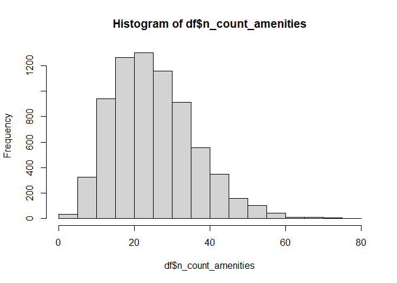

```r
# Common features - Above 90%: d_wifi, d_long_term_stays_allowed, d_essentials, d_kitchen, d_washer, d_tv, d_closet
# Rare features - Below 10%: d_indoor_fireplace, d_pets_allowed, d_smart_lock, d_smoking_allowed, d_breakfast, d_garden

# Add total number of amenities
df$n_count_amenities <- str_count(df$amenities, ",")+1
hist(df$n_count_amenities)
```

### 4. step: Distance from city center

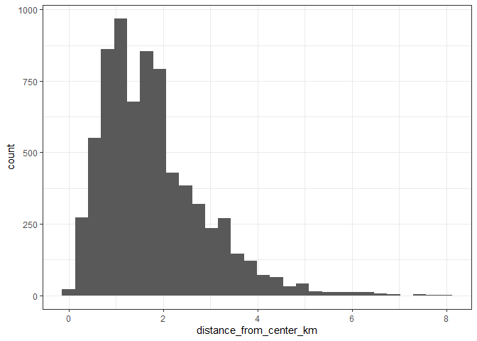

```r
# City center: Plaça de Catalunya (lat: 41.38705287353137, lon: 2.1700683272487105)
lat_center <- 41.38705287353137
lon_center <- 2.1700683272487105

# Add distance in km based on the Great-circle distance formula
df$distance_from_center_km <- acos(sin(lat_center*pi/180)*sin(df$latitude*pi/180) + cos(lat_center*pi/180)*cos(df$latitude*pi/180) * cos((df$longitude*pi/180)-(lon_center*pi/180))) * 6371

ggplot(df, aes(distance_from_center_km)) +
  geom_histogram() +
  theme_bw()
```

```r
# Create distance categories
df$n_distance_from_center_km <- ceiling(df$distance_from_center_km)
df[, .(count = .N), by = .(n_distance_from_center_km)][order(n_distance_from_center_km)]
```

```
##    n_distance_from_center_km count
## 1:                         1  1840
## 2:                         2  2987
## 3:                         3  1395
## 4:                         4   680
## 5:                         5   192
## 6:                         6    52
## 7:                         7    27
## 8:                         8     6
```

```r
datasummary_skim(df$n_distance_from_center_km)
```

Unique (#)

Missing (%)

Mean

SD

Min

Median

Max

data

8

0

2.3

1.1

1.0

2.0

8.0

[figure not shown]

**Note**: It was assumed that the center of the city is the Plaça de Catalunya and distance was measured from its geocoordinates.

### 5. Convert property_type to factor

```r
# Property type
df$f_property_type <- as.factor(df$property_type)

# Summary
datasummary_skim(df$property_type, 'categorical')
```

| data | N | % |
| --- | --- | --- |
| Casa particular | 2 | 0.0 |
| Entire chalet | 1 | 0.0 |
| Entire condominium (condo) | 230 | 3.2 |
| Entire guest suite | 42 | 0.6 |
| Entire guesthouse | 21 | 0.3 |
| Entire home/apt | 1 | 0.0 |
| Entire loft | 258 | 3.6 |
| Entire place | 4 | 0.1 |
| Entire rental unit | 6211 | 86.5 |
| Entire residential home | 41 | 0.6 |
| Entire serviced apartment | 355 | 4.9 |
| Entire townhouse | 10 | 0.1 |
| Tiny house | 3 | 0.0 |

```r
# Neighbourhood
df$f_neighbourhood_group_cleansed <- as.factor(df$neighbourhood_group_cleansed)

# Summary
datasummary_skim(df$f_neighbourhood_group_cleansed, 'categorical')
```

| data | N | % |
| --- | --- | --- |
| Ciutat Vella | 1756 | 24.5 |
| Eixample | 2688 | 37.4 |
| Gràcia | 678 | 9.4 |
| Horta-Guinardó | 152 | 2.1 |
| Les Corts | 129 | 1.8 |
| Nou Barris | 34 | 0.5 |
| Sant Andreu | 68 | 0.9 |
| Sant Martí | 672 | 9.4 |
| Sants-Montjuïc | 731 | 10.2 |
| Sarrià-Sant Gervasi | 271 | 3.8 |

### 7. step: Add naming convention to the rest of the numeric fields

```r
# Numeric
df$n_minimum_nights <- df$minimum_nights
# df$n_maximum_nights <- df$maximum_nights
df$n_bedrooms <- df$bedrooms
df$n_beds <- df$beds
df$n_accommodates <- df$accommodates
df$n_reviews <- df$number_of_reviews
df$n_review_scores_rating <- df$review_scores_rating
```

# Keep only cleaned variables

```r
df_final <- df[, .(id)]

# Numeric vars - 11 vars
numeric_vars <- grep("^n_.*", names(df), value=TRUE)
df_numeric <- df[, .SD, .SDcols =  names(df) %in% numeric_vars]
df_final <- cbind(df_final, df_numeric)

# Factors - 3 vars
factor_vars <- grep("^f_.*", names(df), value=TRUE)
df_factor <- df[, .SD, .SDcols =  names(df) %in% factor_vars]
df_final <- cbind(df_final, df_factor)

# Dummies - 27 vars
binary_vars <- grep("^d_.*", names(df), value=TRUE)
df_binary <- df[, .SD, .SDcols =  names(df) %in% binary_vars]
df_final <- cbind(df_final, df_binary)

# Summary - 65 vars
datasummary_skim(df_final, 'numeric')
```

Unique (#)

Missing (%)

Mean

SD

Min

Median

Max

id

7179

0

28231035.8

17165979.2

23197.0

29671592.0

53713883.0

n_price

340

0

113.1

206.9

8.0

91.0

9999.0

n_bathrooms

9

0

1.3

0.5

0.5

1.0

4.0

[figure not shown]

n_count_amenities

73

0

25.6

10.8

1.0

24.0

80.0

[figure not shown]

n_distance_from_center_km

8

0

2.3

1.1

1.0

2.0

8.0

[figure not shown]

n_minimum_nights

41

0

14.1

16.2

1.0

3.0

90.0

[figure not shown]

n_bedrooms

7

5

1.9

0.8

1.0

2.0

6.0

n_beds

7

2

2.7

1.3

1.0

3.0

6.0

n_accommodates

5

0

4.1

1.4

2.0

4.0

6.0

n_reviews

390

0

44.6

79.9

0.0

7.0

883.0

[figure not shown]

n_review_scores_rating

152

22

4.5

0.6

0.0

4.7

5.0

d_wifi

2

0

1.0

0.1

0.0

1.0

1.0

d_long_term_stays_allowed

2

0

1.0

0.2

0.0

1.0

1.0

d_kitchen

2

0

1.0

0.2

0.0

1.0

1.0

d_washer

2

0

0.9

0.3

0.0

1.0

1.0

d_air_conditioning

2

0

0.9

0.3

0.0

1.0

1.0

d_tv

2

0

0.9

0.2

0.0

1.0

1.0

d_elevator

2

0

0.6

0.5

0.0

1.0

1.0

d_cooking_basics

2

0

0.7

0.5

0.0

1.0

1.0

d_dedicated_workspace

2

0

0.6

0.5

0.0

1.0

1.0

d_breakfast

2

0

0.0

0.1

0.0

0.0

1.0

d_children_friendly

2

0

0.1

0.4

0.0

0.0

1.0

d_garden

2

0

0.1

0.2

0.0

0.0

1.0

d_balcony

2

0

0.4

0.5

0.0

0.0

1.0

d_gym

2

0

0.0

0.1

0.0

0.0

1.0

d_free_parking

2

0

0.0

0.2

0.0

0.0

1.0

d_smoking_allowed

2

0

0.0

0.0

0.0

0.0

1.0

d_private_entrance

2

0

0.2

0.4

0.0

0.0

1.0

d_pool

2

0

0.0

0.2

0.0

0.0

1.0

d_lockbox

2

0

0.1

0.2

0.0

0.0

1.0

d_pets_allowed

2

0

0.0

0.0

0.0

0.0

1.0

d_luggage_dropoff_allowed

2

0

0.2

0.4

0.0

0.0

1.0

```r
datasummary_skim(df_final, 'categorical')
```

|  |  | N | % |
| --- | --- | --- | --- |
| f_bathrooms | 1 | 5439 | 75.8 |
|  | 2 | 1661 | 23.1 |
|  | 3 | 75 | 1.0 |
| f_property_type | Casa particular | 2 | 0.0 |
|  | Entire chalet | 1 | 0.0 |
|  | Entire condominium (condo) | 230 | 3.2 |
|  | Entire guest suite | 42 | 0.6 |
|  | Entire guesthouse | 21 | 0.3 |
|  | Entire home/apt | 1 | 0.0 |
|  | Entire loft | 258 | 3.6 |
|  | Entire place | 4 | 0.1 |
|  | Entire rental unit | 6211 | 86.5 |
|  | Entire residential home | 41 | 0.6 |
|  | Entire serviced apartment | 355 | 4.9 |
|  | Entire townhouse | 10 | 0.1 |
|  | Tiny house | 3 | 0.0 |
| f_neighbourhood_group_cleansed | Ciutat Vella | 1756 | 24.5 |
|  | Eixample | 2688 | 37.4 |
|  | Gràcia | 678 | 9.4 |
|  | Horta-Guinardó | 152 | 2.1 |
|  | Les Corts | 129 | 1.8 |
|  | Nou Barris | 34 | 0.5 |
|  | Sant Andreu | 68 | 0.9 |
|  | Sant Martí | 672 | 9.4 |
|  | Sants-Montjuïc | 731 | 10.2 |
|  | Sarrià-Sant Gervasi | 271 | 3.8 |

# Managing missings

```r
# Missings
missings <- sapply(df_final, function(x) sum(is.na(x)))
missings[missings > 0]
```

```
##            n_bathrooms             n_bedrooms                 n_beds
##                      1                    338                    133
## n_review_scores_rating            f_bathrooms
##                   1585                      4
```

```r
# n_bathrooms, n_bedrooms, n_beds, n_review_scores_rating,  f_bathrooms
```

### 1. step: Missing bathrooms

```r
# Missing bathrooms - 1 obs. - Add 1 assuming that apartments have at least one bathroom
df_final$flg_n_bathrooms <- ifelse(is.na(df_final$n_bathrooms), 1, 0) # 1 missing
df_final$n_bathrooms <- ifelse(is.na(df_final$n_bathrooms), median(df_final$n_bathrooms, na.rm = T), df_final$n_bathrooms)
df_final$f_bathrooms <- ifelse(is.na(df_final$f_bathrooms), 2, df_final$f_bathrooms)

# Summary
df_final[, .(count = .N), by = .(n_bathrooms, f_bathrooms, flg_n_bathrooms)][order(flg_n_bathrooms, n_bathrooms)]
```

```
##    n_bathrooms f_bathrooms flg_n_bathrooms count
## 1:         0.5           2               0     3
## 2:         1.0           1               0  5035
## 3:         1.5           1               0   404
## 4:         2.0           2               0  1620
## 5:         2.5           2               0    41
## 6:         3.0           3               0    63
## 7:         3.5           3               0     7
## 8:         4.0           3               0     5
## 9:         1.0           2               1     1
```

### 2. step: Missing bedrooms

```r
# Missing bedrooms - 340 obs. - Add 0 assuming that apartments do not have separate bedrooms (studio)
df_final$flg_n_bedrooms <- ifelse(is.na(df_final$n_bedrooms),1, 0) # 340 missing
df_final$n_bedrooms <- ifelse(is.na(df_final$n_bedrooms),0, df_final$n_bedrooms)

# Summary
df_final[, .(count = .N), by = .(n_bedrooms, flg_n_bedrooms)][order(flg_n_bedrooms, n_bedrooms)]
```

```
##    n_bedrooms flg_n_bedrooms count
## 1:          1              0  2156
## 2:          2              0  3038
## 3:          3              0  1495
## 4:          4              0   148
## 5:          5              0     3
## 6:          6              0     1
## 7:          0              1   338
```

### 3. step: Missing beds

```r
# Missing beds - 134 obs. - Add number of accommodates to missing beds
df_final[is.na(n_beds), .(count = .N), by = .(n_accommodates)]
```

```
##    n_accommodates count
## 1:              6    13
## 2:              3    14
## 3:              4    44
## 4:              5     9
## 5:              2    53
```

```r
df_final$flg_n_beds <- ifelse(is.na(df_final$n_beds),1, 0)  # 134 missing
df_final$n_beds <-  ifelse(is.na(df_final$n_beds),
                           df_final$n_accommodates, df_final$n_beds)

# df_final$n_ln_beds <- log(df_final$n_beds)
# df_final$flg_n_ln_beds <- ifelse(is.na(df_final$n_ln_beds),1, 0) # 134 missing
# df_final$n_ln_beds <- ifelse(is.na(df_final$n_ln_beds),0, df_final$n_ln_beds)

# Summary
df_final[, .(count = .N), by = .(n_beds, flg_n_beds)][order(flg_n_beds, n_beds)]
```

```
##     n_beds flg_n_beds count
##  1:      1          0  1359
##  2:      2          0  1964
##  3:      3          0  1835
##  4:      4          0  1172
##  5:      5          0   504
##  6:      6          0   212
##  7:      2          1    53
##  8:      3          1    14
##  9:      4          1    44
## 10:      5          1     9
## 11:      6          1    13
```

### 4. step: Missing n_review_scores_rating

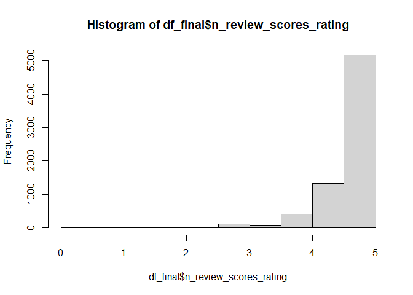

```r
#  Missing n_review_scores_rating - 1631 obs. - Add median
df_final$flg_n_review_scores_rating <- ifelse(is.na(df_final$n_review_scores_rating),1, 0) # 1631 missing
df_final$n_review_scores_rating <-  ifelse(is.na(df_final$n_review_scores_rating),
                                           median(df_final$n_review_scores_rating, na.rm = T), df_final$n_review_scores_rating)
# Summary
hist(df_final$n_review_scores_rating)
```

**Note**: Missing rate is high in this variable but it is expected to be an important predictor hence kept for the analysis.

```r
# Check missings again
missings <- sapply(df_final, function(x) sum(is.na(x)))
missings[missings > 0] # 0 missings now
```

```
## named integer(0)
```

# Variable categorization

### 1. step: n_reviews

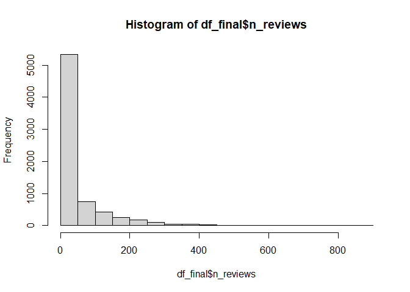

```r
# n_reviews: [0], [1-51], [51-100] [100+]
hist(df_final$n_reviews)
```

```r
df_final$f_reviews <- cut(df_final$n_reviews, c(0,1,51,101,9999), labels=c(0,1,2,3), right = F)
df_final[, .(count = .N, min = min(n_reviews), max = max(n_reviews), avg_price = mean(n_price)), by = .(f_reviews)]
```

```
##    f_reviews count min max avg_price
## 1:         2   749  51 100  118.4059
## 2:         3  1103 101 883  110.7389
## 3:         1  3742   1  50  105.7953
## 4:         0  1585   0   0  129.3230
```

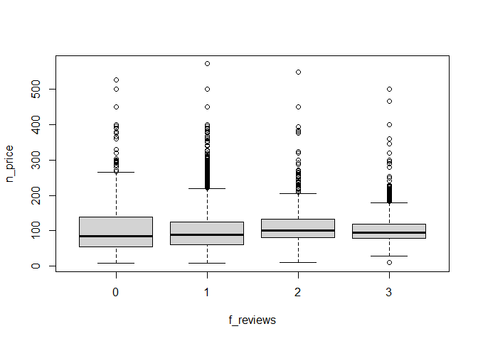

```r
# Check relationship with price (excl. extremes)
boxplot(n_price ~ f_reviews, data=df_final[n_price < 600])
```

**Note**: Few listings above 100 reviews, group them together.

### 2. step: n_minimum_night

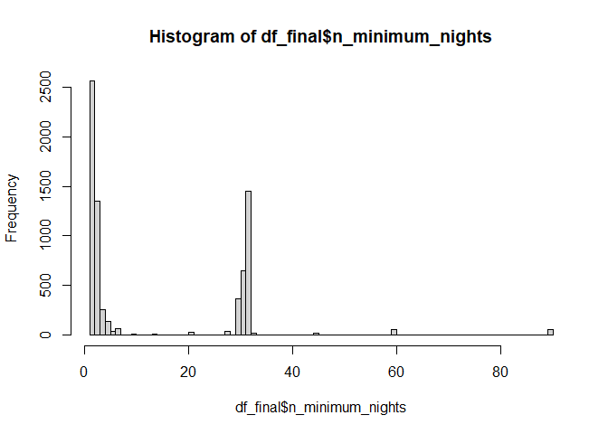

```r
# n_minimum_nights: [1],[2-7],[8-14],[14+]
hist(df_final$n_minimum_nights, breaks = 100)
```

```r
df_final$f_minimum_nights <- cut(df_final$n_minimum_nights, c(1,2,8,9999), labels=c(1,2,3), right = F)
df_final[, .(count = .N, min = min(n_minimum_nights), max = max(n_minimum_nights), avg_price = mean(n_price)), by = .(f_minimum_nights)]
```

```
##    f_minimum_nights count min max avg_price
## 1:                2  2802   2   7 124.55817
## 2:                1  1608   1   1 126.06157
## 3:                3  2769   8  90  93.88769
```

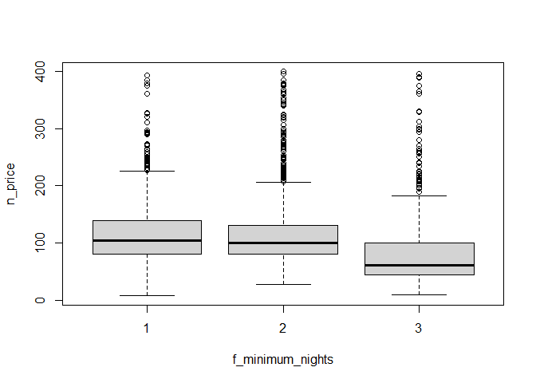

```r
# Check relationship with price (excl. extremes)
boxplot(n_price ~ f_minimum_nights, data=df_final[n_price < 400])
```

**Note**: This variable is most probably not for measuring the minimum nights that the guests should spend at the apartment but the number of available nights. It is better to exclude this variable from later analysis.

### 3. step: Property type

```r
# Create categories based on mean price
df_final[, .(count = .N, mean_price = mean(n_price)), by = .(f_property_type)][order(mean_price)]
```

```
##                f_property_type count mean_price
##  1:              Entire chalet     1   46.00000
##  2:          Entire guesthouse    21   58.52381
##  3:                 Tiny house     3   69.00000
##  4:         Entire guest suite    42   69.76190
##  5:                Entire loft   258   83.94961
##  6:               Entire place     4   90.00000
##  7:            Casa particular     2   95.00000
##  8: Entire condominium (condo)   230   95.14348
##  9:            Entire home/apt     1  102.00000
## 10:           Entire townhouse    10  102.30000
## 11:         Entire rental unit  6211  113.49267
## 12:  Entire serviced apartment   355  138.01127
## 13:    Entire residential home    41  199.21951
```

```r
df_final <- df_final %>% mutate(
  f_property_type = as.character(f_property_type),
  f_property_type2 = case_when(
    f_property_type %in% c("Entire rental unit", "Entire home/apt", "Entire residential home", "Entire townhouse", "Casa particular", "Entire place") ~ "Entire home / Apartment",
    f_property_type %in% c("Entire chalet", "Tiny house", "Entire guesthouse", "Entire guest suite") ~ "Entire guesthouse / chalet",
    TRUE ~ f_property_type))

df_final[, .(count = .N, mean_price = mean(n_price)), by = .(f_property_type2)][order(mean_price)]
```

```
##              f_property_type2 count mean_price
## 1: Entire guesthouse / chalet    67   65.85075
## 2:                Entire loft   258   83.94961
## 3: Entire condominium (condo)   230   95.14348
## 4:    Entire home / Apartment  6269  114.01276
## 5:  Entire serviced apartment   355  138.01127
```

```r
# Overwrite the original field
df_final$f_property_type <- df_final$f_property_type2
df_final[,f_property_type2:=NULL]
```

**Note**: Small property type were merged to the bigger groups based on their average prices.

# Final check

```r
# Numeric
numeric_vars <- grep("^n_.*", names(df_final), value=TRUE)
df_numeric <- df_final[, .SD, .SDcols =  names(df_final) %in% numeric_vars]
datasummary_skim(df_numeric, fmt =  '%.3f' )
```

Unique (#)

Missing (%)

Mean

SD

Min

Median

Max

n_price

340

0

113.065

206.859

8.000

91.000

9999.000

n_bathrooms

8

0

1.284

0.468

0.500

1.000

4.000

[figure not shown]

n_count_amenities

73

0

25.640

10.779

1.000

24.000

80.000

[figure not shown]

n_distance_from_center_km

8

0

2.260

1.115

1.000

2.000

8.000

[figure not shown]

n_minimum_nights

41

0

14.124

16.201

1.000

3.000

90.000

[figure not shown]

n_bedrooms

7

0

1.857

0.875

0.000

2.000

6.000

n_beds

6

0

2.747

1.308

1.000

3.000

6.000

n_accommodates

5

0

4.060

1.350

2.000

4.000

6.000

n_reviews

390

0

44.611

79.874

0.000

7.000

883.000

[figure not shown]

n_review_scores_rating

151

0

4.549

0.534

0.000

4.660

5.000

```r
# Dummies
dummy_vars <- grep("^d_.*", names(df_final), value=TRUE)
df_dummy <- df_final[, .SD, .SDcols =  names(df_final) %in% dummy_vars]
datasummary_skim(df_dummy, fmt =  '%.3f' )
```

|  | Unique (#) | Missing (%) | Mean | SD | Min | Median | Max |  |
| --- | --- | --- | --- | --- | --- | --- | --- | --- |
| d_wifi | 2 | 0 | 0.984 | 0.126 | 0.000 | 1.000 | 1.000 |  |
| d_long_term_stays_allowed | 2 | 0 | 0.966 | 0.181 | 0.000 | 1.000 | 1.000 |  |
| d_kitchen | 2 | 0 | 0.973 | 0.162 | 0.000 | 1.000 | 1.000 |  |
| d_washer | 2 | 0 | 0.931 | 0.253 | 0.000 | 1.000 | 1.000 |  |
| d_air_conditioning | 2 | 0 | 0.894 | 0.308 | 0.000 | 1.000 | 1.000 |  |
| d_tv | 2 | 0 | 0.947 | 0.224 | 0.000 | 1.000 | 1.000 |  |
| d_elevator | 2 | 0 | 0.593 | 0.491 | 0.000 | 1.000 | 1.000 |  |
| d_cooking_basics | 2 | 0 | 0.709 | 0.454 | 0.000 | 1.000 | 1.000 |  |
| d_dedicated_workspace | 2 | 0 | 0.588 | 0.492 | 0.000 | 1.000 | 1.000 |  |
| d_breakfast | 2 | 0 | 0.013 | 0.115 | 0.000 | 0.000 | 1.000 |  |
| d_children_friendly | 2 | 0 | 0.148 | 0.355 | 0.000 | 0.000 | 1.000 |  |
| d_garden | 2 | 0 | 0.052 | 0.222 | 0.000 | 0.000 | 1.000 |  |
| d_balcony | 2 | 0 | 0.443 | 0.497 | 0.000 | 0.000 | 1.000 |  |
| d_gym | 2 | 0 | 0.015 | 0.120 | 0.000 | 0.000 | 1.000 |  |
| d_free_parking | 2 | 0 | 0.029 | 0.169 | 0.000 | 0.000 | 1.000 |  |
| d_smoking_allowed | 2 | 0 | 0.002 | 0.041 | 0.000 | 0.000 | 1.000 |  |
| d_private_entrance | 2 | 0 | 0.192 | 0.394 | 0.000 | 0.000 | 1.000 |  |
| d_pool | 2 | 0 | 0.036 | 0.188 | 0.000 | 0.000 | 1.000 |  |
| d_lockbox | 2 | 0 | 0.053 | 0.225 | 0.000 | 0.000 | 1.000 |  |
| d_pets_allowed | 2 | 0 | 0.002 | 0.046 | 0.000 | 0.000 | 1.000 |  |
| d_luggage_dropoff_allowed | 2 | 0 | 0.206 | 0.405 | 0.000 | 0.000 | 1.000 |  |

```r
# Factors
factor_vars <- grep("^f_.*", names(df_final), value=TRUE)
df_factor <- df_final[, .SD, .SDcols =  names(df_final) %in% factor_vars]
datasummary_skim(df_factor, fmt =  '%.3f' , 'categorical')
```

|  |  | N | % |
| --- | --- | --- | --- |
| f_property_type | Entire condominium (condo) | 230 | 3.204 |
|  | Entire guesthouse / chalet | 67 | 0.933 |
|  | Entire home / Apartment | 6269 | 87.324 |
|  | Entire loft | 258 | 3.594 |
|  | Entire serviced apartment | 355 | 4.945 |
| f_neighbourhood_group_cleansed | Ciutat Vella | 1756 | 24.460 |
|  | Eixample | 2688 | 37.443 |
|  | Gràcia | 678 | 9.444 |
|  | Horta-Guinardó | 152 | 2.117 |
|  | Les Corts | 129 | 1.797 |
|  | Nou Barris | 34 | 0.474 |
|  | Sant Andreu | 68 | 0.947 |
|  | Sant Martí | 672 | 9.361 |
|  | Sants-Montjuïc | 731 | 10.182 |
|  | Sarrià-Sant Gervasi | 271 | 3.775 |
| f_reviews | 0 | 1585 | 22.078 |
|  | 1 | 3742 | 52.124 |
|  | 2 | 749 | 10.433 |
|  | 3 | 1103 | 15.364 |
| f_minimum_nights | 1 | 1608 | 22.399 |
|  | 2 | 2802 | 39.031 |
|  | 3 | 2769 | 38.571 |

# Create work file

```r
# Drop fields
drops <- c("n_bathrooms", "n_reviews", "n_minimum_nights")
df_final <- df_final[, (drops) := NULL]

# Create work file
write.csv(df_final, file = paste0(data_work,'/airbnb_barcelona_20211207_cleaned.csv'))
```